# DNA methylation desing to discovery 2026

Dr. Gilles Gasparoni, Lukas Laufer, Nihit Aggarwal

### Intialization

##### Reload packages and rnb sets

```r
lapply(packages_to_load, require, character.only=TRUE)
```

```
[[1]]
[1] TRUE

[[2]]
[1] TRUE

[[3]]
[1] TRUE

[[4]]
[1] TRUE

[[5]]
[1] TRUE

[[6]]
[1] TRUE

[[7]]
[1] FALSE
```

### Downstream anaylsis

#### Dimensionality reduction

```r
#let's use dimensionality reduction to look at data variation
dred.sites <- rnb.execute.dreduction(rnb)
```

```
Calculated MDS coordinates using manhattan distance
Calculated MDS coordinates using euclidean distance
```

```r
dred.promoters <- rnb.execute.dreduction(rnb, target = "promoters")
```

```
Calculated MDS coordinates using manhattan distance
Calculated MDS coordinates using euclidean distance
```

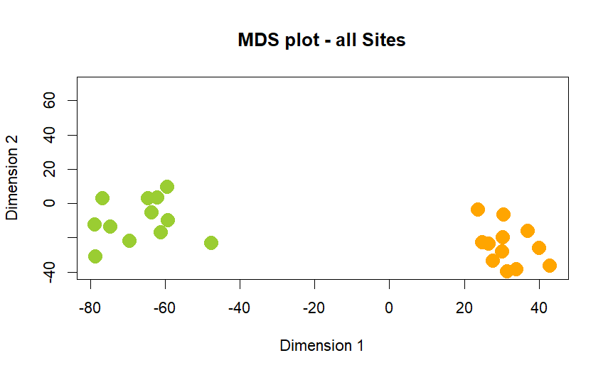

```r
dred <- list(sites = dred.sites, promoters = dred.promoters)
sample.colors <- ifelse(pheno(rnb)$CellType == "Glia", "orange", "yellowgreen")

#plot MDS for Glia an d Neurons
plot(dred[["sites"]]$mds$euclidean, col = sample.colors, xlab = "Dimension 1", ylab = "Dimension 2", cex = 2, pch = 19,
     main = "MDS plot - all Sites")
```

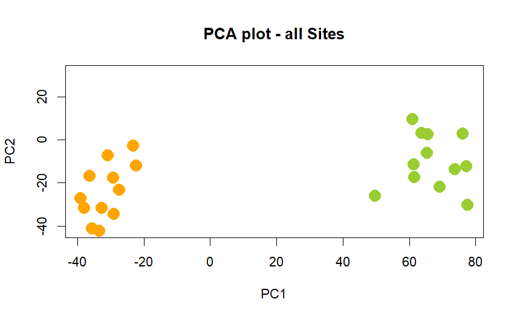

```r
plot(dred[["sites"]]$pca$x, col = sample.colors, xlab = "PC1", ylab = "PC2", cex = 2, pch = 19,
     main = "PCA plot - all Sites")
```

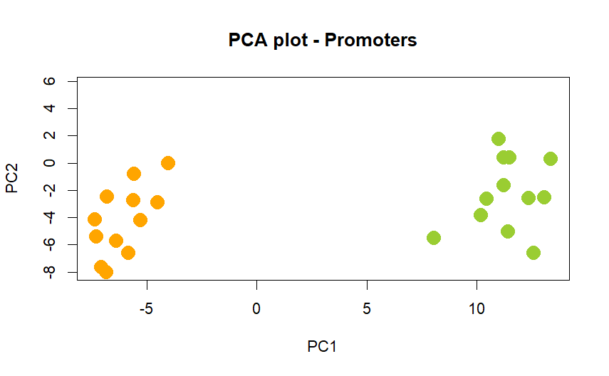

```r
plot(dred[["promoters"]]$pca$x, col = sample.colors, xlab = "PC1", ylab = "PC2", cex = 2, pch = 19,
     main = "PCA plot - Promoters")
```

#### Batch Effects Assessment

Check for batch effects by correlating PCA coordinates with known sample parameters.

```r
#check if have some batch effects by correlation PCA and known sample parameters
# e.g. "Group" biologic samplegroups - "Type = 'sorted' vs 'unsorted'
assoc <- rnb.execute.batcheffects(rnb, pcoordinates = dred)
```

```
2026-01-15 18:17:34     Inf  STATUS STARTED Tests for Associations
```

```
2026-01-15 18:17:34     Inf    INFO     Testing the following traits for associations: DonorID; Sex; Age; Type; CellType; Tissue; Diagnosis; Group; stage; Sentrix_ID; Sentrix_Position; AD_vs_CTRL_Neuron; AD_vs_CTRL_Glia; AD_vs_CTRL_FC; AD_vs_CTRL_TC; Predicted Male Probability; Predicted Sex; Genome…
```

```
2026-01-15 18:17:35     Inf  STATUS     Created 10000 sample permutations
```

```
2026-01-15 18:18:10     Inf  STATUS     Computed correlations between principal components and traits.
```

```
2026-01-15 18:18:25     Inf  STATUS     Computed pairwise correlations between traits.
```

```
2026-01-15 18:18:25     Inf  STATUS COMPLETED Tests for Associations
```

```r
str(assoc)
```

```
List of 3
 $ permutations: int [1:64, 1:10000] 1 2 3 4 5 6 7 8 9 10 ...
 $ pc          :List of 2
  ..$ sites    :List of 4
  .. ..$ failures    : chr [1:21, 1:8] NA NA NA NA ...
  .. .. ..- attr(*, "dimnames")=List of 2
  .. .. .. ..$                    : chr [1:21] "DonorID" "Sex" "Age" "Type" ...
  .. .. .. ..$ Principal component: chr [1:8] "1" "2" "3" "4" ...
  .. ..$ tests       : chr [1:21, 1:8] "Kruskal-Wallis" "Wilcoxon" "Correlation" "Wilcoxon" ...
  .. .. ..- attr(*, "dimnames")=List of 2
  .. .. .. ..$                    : chr [1:21] "DonorID" "Sex" "Age" "Type" ...
  .. .. .. ..$ Principal component: chr [1:8] "1" "2" "3" "4" ...
  .. ..$ correlations: num [1:21, 1:8] NA NA 0.195 NA NA ...
  .. .. ..- attr(*, "dimnames")=List of 2
  .. .. .. ..$                    : chr [1:21] "DonorID" "Sex" "Age" "Type" ...
  .. .. .. ..$ Principal component: chr [1:8] "1" "2" "3" "4" ...
  .. ..$ pvalues     : num [1:21, 1:8] 1.00 3.59e-01 1.24e-01 8.96e-01 7.40e-07 ...
  .. .. ..- attr(*, "dimnames")=List of 2
  .. .. .. ..$                    : chr [1:21] "DonorID" "Sex" "Age" "Type" ...
  .. .. .. ..$ Principal component: chr [1:8] "1" "2" "3" "4" ...
  ..$ promoters:List of 4
  .. ..$ failures    : chr [1:21, 1:8] NA NA NA NA ...
  .. .. ..- attr(*, "dimnames")=List of 2
  .. .. .. ..$                    : chr [1:21] "DonorID" "Sex" "Age" "Type" ...
  .. .. .. ..$ Principal component: chr [1:8] "1" "2" "3" "4" ...
  .. ..$ tests       : chr [1:21, 1:8] "Kruskal-Wallis" "Wilcoxon" "Correlation" "Wilcoxon" ...
  .. .. ..- attr(*, "dimnames")=List of 2
  .. .. .. ..$                    : chr [1:21] "DonorID" "Sex" "Age" "Type" ...
  .. .. .. ..$ Principal component: chr [1:8] "1" "2" "3" "4" ...
  .. ..$ correlations: num [1:21, 1:8] NA NA 0.185 NA NA ...
  .. .. ..- attr(*, "dimnames")=List of 2
  .. .. .. ..$                    : chr [1:21] "DonorID" "Sex" "Age" "Type" ...
  .. .. .. ..$ Principal component: chr [1:8] "1" "2" "3" "4" ...
  .. ..$ pvalues     : num [1:21, 1:8] 1.00 4.26e-01 1.45e-01 9.40e-01 7.40e-07 ...
  .. .. ..- attr(*, "dimnames")=List of 2
  .. .. .. ..$                    : chr [1:21] "DonorID" "Sex" "Age" "Type" ...
  .. .. .. ..$ Principal component: chr [1:8] "1" "2" "3" "4" ...
 $ traits      :List of 4
  ..$ failures    : chr [1:21, 1:21] NA NA NA NA ...
  .. ..- attr(*, "dimnames")=List of 2
  .. .. ..$ : chr [1:21] "DonorID" "Sex" "Age" "Type" ...
  .. .. ..$ : chr [1:21] "DonorID" "Sex" "Age" "Type" ...
  ..$ tests       : chr [1:21, 1:21] NA "Fisher" "Kruskal-Wallis" "Fisher" ...
  .. ..- attr(*, "dimnames")=List of 2
  .. .. ..$ : chr [1:21] "DonorID" "Sex" "Age" "Type" ...
  .. .. ..$ : chr [1:21] "DonorID" "Sex" "Age" "Type" ...
  ..$ correlations: num [1:21, 1:21] NA NA NA NA NA NA NA NA NA NA ...
  .. ..- attr(*, "dimnames")=List of 2
  .. .. ..$ : chr [1:21] "DonorID" "Sex" "Age" "Type" ...
  .. .. ..$ : chr [1:21] "DonorID" "Sex" "Age" "Type" ...
  ..$ pvalues     : num [1:21, 1:21] NA 0.00002 0.00126 0.00002 1 ...
  .. ..- attr(*, "dimnames")=List of 2
  .. .. ..$ : chr [1:21] "DonorID" "Sex" "Age" "Type" ...
  .. .. ..$ : chr [1:21] "DonorID" "Sex" "Age" "Type" ...
```

```r
rnb.options(exploratory.columns=c("Group", "Type"))
assoc.qc <- rnb.execute.batch.qc(rnb, pcoordinates=dred)
```

```
2026-01-15 18:18:27     Inf  STATUS Computed associations between 8 principal component(s) and bisulfite conversion I for sites
```

```
2026-01-15 18:18:27     Inf  STATUS Computed associations between 8 principal component(s) and bisulfite conversion II for sites
```

```
2026-01-15 18:18:27     Inf  STATUS Computed associations between 8 principal component(s) and extension for sites
```

```
2026-01-15 18:18:27     Inf  STATUS Computed associations between 8 principal component(s) and hybridization for sites
```

```
2026-01-15 18:18:27     Inf  STATUS Computed associations between 8 principal component(s) and non-polymorphic for sites
```

```
2026-01-15 18:18:27     Inf  STATUS Computed associations between 8 principal component(s) and specificity I for sites
```

```
2026-01-15 18:18:27     Inf  STATUS Computed associations between 8 principal component(s) and specificity II for sites
```

```
2026-01-15 18:18:27     Inf  STATUS Computed associations between 8 principal component(s) and staining for sites
```

```
2026-01-15 18:18:27     Inf  STATUS Computed associations between 8 principal component(s) and target removal for sites
```

```
2026-01-15 18:18:27     Inf  STATUS Computed associations between 8 principal component(s) and bisulfite conversion I for promoters
```

```
2026-01-15 18:18:27     Inf  STATUS Computed associations between 8 principal component(s) and bisulfite conversion II for promoters
```

```
2026-01-15 18:18:27     Inf  STATUS Computed associations between 8 principal component(s) and extension for promoters
```

```
2026-01-15 18:18:27     Inf  STATUS Computed associations between 8 principal component(s) and hybridization for promoters
```

```
2026-01-15 18:18:27     Inf  STATUS Computed associations between 8 principal component(s) and non-polymorphic for promoters
```

```
2026-01-15 18:18:27     Inf  STATUS Computed associations between 8 principal component(s) and specificity I for promoters
```

```
2026-01-15 18:18:27     Inf  STATUS Computed associations between 8 principal component(s) and specificity II for promoters
```

```
2026-01-15 18:18:27     Inf  STATUS Computed associations between 8 principal component(s) and staining for promoters
```

```
2026-01-15 18:18:27     Inf  STATUS Computed associations between 8 principal component(s) and target removal for promoters
```

#### Plot Probe Type Deviation

Visualize methylation deviation by probe types (e.g., Type I vs Type II) in a PDF file.

```r
setwd("D:/Work/Epigenetics/Workshops/2024_deNBI-DNA_methylation_design_to_discovery/")
probe.types <- as.character(annotation(rnb)[, "Design"])
pdf(file = "deviationPlot_probeType.pdf", width = 11)
deviation.plot.beta(meth(rnb),
                    probe.types,
                    c.legend = c("I" = "blue", "II" = "red")
                    )
dev.off()
```

#### Clustering and Heatmap

Cluster the samples based on methylation values from sites or promoters, and visualize the clustered promoters as a heatmap

```r
#cluster the samples based on indivudal sites or promoters
clusterings.sites <- rnb.execute.clustering(rnb, region.type = "sites")
```

```
2026-01-15 18:25:27     Inf  STATUS Performed clustering on sites using correlation as a distance metric
```

```
2026-01-15 18:25:43     Inf  STATUS Performed clustering on sites using manhattan as a distance metric
```

```
2026-01-15 18:25:58     Inf  STATUS Performed clustering on sites using euclidean as a distance metric
```

```r
clusterings.promoters <- rnb.execute.clustering(rnb, region.type = "promoters")
```

```
2026-01-15 18:25:58     Inf  STATUS Performed clustering on promoters using correlation as a distance metric
```

```
2026-01-15 18:25:59     Inf  STATUS Performed clustering on promoters using manhattan as a distance metric
```

```
2026-01-15 18:26:02     Inf  STATUS Performed clustering on promoters using euclidean as a distance metric
```

```r
# Get the methylation values
X <- meth(rnb, type = "promoters")[1:100, ]
# Convert the clustering result to a dendrogram
# Index 7 holds euclidean distance, average linkage clustering
cresult <- clusterings.promoters[[7]]@result
attr(cresult, "class") <- "hclust"
cresult <- as.dendrogram(cresult)

# Save the heatmap as pdf file
pdf(file="promoter_heatmap.pdf")
heatmap.2(X, Rowv = TRUE, Colv = cresult, dendrogram = "both", scale = "none", trace = "none")
dev.off()
```

### Differential analysis

```r
# if we want to compare Neuron vs Glia cells from Controls only,
# we will need to add a new column to pheno data to establish this comparison

#first we create a dedicated sample scheme
SortedControl <- ifelse(pheno(rnb)[, "Diagnosis"] == "CTRL" & pheno(rnb)[, "CellType"] == "Glia", "Glia_CTRL",
                        ifelse(pheno(rnb)[, "Diagnosis"] == "CTRL" & pheno(rnb)[, "CellType"] == "Neuron", "Neuron_CTRL", NA)
)

#now we add the scheme as a new column to the phenotypic data
#rnb <- addPheno(rnb, SortedControl, "Neuron_CTRL_vs_Glia_CTRL")

# Specify the sample annotation table columns for which
# differential methylation is to be computed
rnb.options("differential.site.test.method" = "limma") #'limma' or 'ttest'

cmp.cols_sorted <- c("Neuron_CTRL_vs_Glia_CTRL", "AD_vs_CTRL_Neuron","AD_vs_CTRL_Glia")
# Specify the region types
reg.types <- c("genes", "promoters")

# Conduct the analysis #takes 5 minutes
diffmeth_sorted <- rnb.execute.computeDiffMeth(x = rnb,
                                               pheno.cols = cmp.cols_sorted,
                                               region.types = reg.types,
                                               columns.adj = "Age",
                                               adjust.sva = FALSE,
                                               skip.sites = FALSE,
                                               adjust.celltype = FALSE)
```

```
2026-01-15 18:54:30     Inf  STATUS STARTED Retrieving comparison info
```

```
2026-01-15 18:54:30     Inf  STATUS COMPLETED Retrieving comparison info
```

```
2026-01-15 18:54:30     Inf  STATUS STARTED Computing differential methylation tables
```

```
2026-01-15 18:54:30     Inf  STATUS     STARTED Comparing: Glia_CTRL vs. Neuron_CTRL (based on Neuron_CTRL_vs_Glia_CTRL)
```

```
2026-01-15 18:54:30     Inf  STATUS         STARTED Computing Differential Methylation Table
```

```
2026-01-15 18:54:30     Inf    INFO             Adjusting for covariates: Age
```

```
2026-01-15 18:54:30     Inf    INFO             Conducting differential analysis using limma
```

```
2026-01-15 18:54:39     Inf  STATUS         COMPLETED Computing Differential Methylation Table
```

```
2026-01-15 18:54:40     Inf  STATUS         STARTED Computing Differential Methylation Tables (Region Level)
```

```
2026-01-15 18:54:59     Inf  STATUS             Computed table for genes
```

```
2026-01-15 18:55:16     Inf  STATUS             Computed table for promoters
```

```
2026-01-15 18:55:16     Inf  STATUS         COMPLETED Computing Differential Methylation Tables (Region Level)
```

```
2026-01-15 18:55:16     Inf  STATUS     COMPLETED Comparing: Glia_CTRL vs. Neuron_CTRL (based on Neuron_CTRL_vs_Glia_CTRL)
```

```
2026-01-15 18:55:16     Inf  STATUS     STARTED Comparing: Neuron_AD vs. Neuron_CTRL (based on AD_vs_CTRL_Neuron)
```

```
2026-01-15 18:55:16     Inf  STATUS         STARTED Computing Differential Methylation Table
```

```
2026-01-15 18:55:16     Inf    INFO             Adjusting for covariates: Age
```

```
2026-01-15 18:55:16     Inf    INFO             Conducting differential analysis using limma
```

```
2026-01-15 18:55:25     Inf  STATUS         COMPLETED Computing Differential Methylation Table
```

```
2026-01-15 18:55:26     Inf  STATUS         STARTED Computing Differential Methylation Tables (Region Level)
```

```
2026-01-15 18:55:45     Inf  STATUS             Computed table for genes
```

```
2026-01-15 18:56:01     Inf  STATUS             Computed table for promoters
```

```
2026-01-15 18:56:01     Inf  STATUS         COMPLETED Computing Differential Methylation Tables (Region Level)
```

```
2026-01-15 18:56:01     Inf  STATUS     COMPLETED Comparing: Neuron_AD vs. Neuron_CTRL (based on AD_vs_CTRL_Neuron)
```

```
2026-01-15 18:56:01     Inf  STATUS     STARTED Comparing: Glia_AD vs. Glia_CTRL (based on AD_vs_CTRL_Glia)
```

```
2026-01-15 18:56:01     Inf  STATUS         STARTED Computing Differential Methylation Table
```

```
2026-01-15 18:56:02     Inf    INFO             Adjusting for covariates: Age
```

```
2026-01-15 18:56:02     Inf    INFO             Conducting differential analysis using limma
```

```
2026-01-15 18:56:11     Inf  STATUS         COMPLETED Computing Differential Methylation Table
```

```
2026-01-15 18:56:12     Inf  STATUS         STARTED Computing Differential Methylation Tables (Region Level)
```

```
2026-01-15 18:56:31     Inf  STATUS             Computed table for genes
```

```
2026-01-15 18:56:48     Inf  STATUS             Computed table for promoters
```

```
2026-01-15 18:56:48     Inf  STATUS         COMPLETED Computing Differential Methylation Tables (Region Level)
```

```
2026-01-15 18:56:48     Inf  STATUS     COMPLETED Comparing: Glia_AD vs. Glia_CTRL (based on AD_vs_CTRL_Glia)
```

```
2026-01-15 18:56:48     Inf  STATUS COMPLETED Computing differential methylation tables
```

```r
#save the results as compressed tables
save.rnb.diffmeth(object = diffmeth_sorted, path = "D:/Work/Epigenetics/Workshops/2024_deNBI-DNA_methylation_design_to_discovery/analysis/rnbDiffMeth.Rdata")
```

```
2026-01-15 18:56:48     Inf WARNING Zip not found on this Windows system, this RnBDiffMeth object will not be saved. See the instructions for installing ZIP on Windows in the FAQ section of the RnBeads website.
```

```r
cmp.cols_tissue <- c("AD_vs_CTRL_FC","AD_vs_CTRL_TC")
# Specify the region types
reg.types <- c("genes", "promoters")
# Conduct the analysis
diffmeth_tissue <- rnb.execute.computeDiffMeth(x = rnb,
                                               pheno.cols = cmp.cols_tissue,
                                               region.types = reg.types,
                                               columns.adj = c("Age", "Sex"),
                                               adjust.sva = FALSE,
                                               pheno.cols.adjust.sva = "NeuronalContent",
                                               skip.sites = FALSE,
                                               adjust.celltype = TRUE)
```

```
2026-01-15 18:56:48     Inf  STATUS STARTED Retrieving comparison info
```

```
2026-01-15 18:56:48     Inf  STATUS COMPLETED Retrieving comparison info
```

```
2026-01-15 18:56:48     Inf  STATUS STARTED Computing differential methylation tables
```

```
2026-01-15 18:56:48     Inf  STATUS     STARTED Comparing: FrontalCortex_AD vs. FrontalCortex_CTRL (based on AD_vs_CTRL_FC)
```

```
2026-01-15 18:56:48     Inf  STATUS         STARTED Computing Differential Methylation Table
```

```
2026-01-15 18:56:49     Inf    INFO             Adjusting for covariates: Age,Sex,ct_1,ct_2
```

```
2026-01-15 18:56:49     Inf    INFO             Conducting differential analysis using limma
```

```
2026-01-15 18:56:58     Inf  STATUS         COMPLETED Computing Differential Methylation Table
```

```
2026-01-15 18:56:59     Inf  STATUS         STARTED Computing Differential Methylation Tables (Region Level)
```

```
2026-01-15 18:57:18     Inf  STATUS             Computed table for genes
```

```
2026-01-15 18:57:35     Inf  STATUS             Computed table for promoters
```

```
2026-01-15 18:57:35     Inf  STATUS         COMPLETED Computing Differential Methylation Tables (Region Level)
```

```
2026-01-15 18:57:35     Inf  STATUS     COMPLETED Comparing: FrontalCortex_AD vs. FrontalCortex_CTRL (based on AD_vs_CTRL_FC)
```

```
2026-01-15 18:57:35     Inf  STATUS     STARTED Comparing: TemporalCortex_AD vs. TemporalCortex_CTRL (based on AD_vs_CTRL_TC)
```

```
2026-01-15 18:57:35     Inf  STATUS         STARTED Computing Differential Methylation Table
```

```
2026-01-15 18:57:36     Inf    INFO             Adjusting for covariates: Age,Sex,ct_1,ct_2
```

```
2026-01-15 18:57:36     Inf    INFO             Conducting differential analysis using limma
```

```
2026-01-15 18:57:46     Inf  STATUS         COMPLETED Computing Differential Methylation Table
```

```
2026-01-15 18:57:46     Inf  STATUS         STARTED Computing Differential Methylation Tables (Region Level)
```

```
2026-01-15 18:58:06     Inf  STATUS             Computed table for genes
```

```
2026-01-15 18:58:23     Inf  STATUS             Computed table for promoters
```

```
2026-01-15 18:58:23     Inf  STATUS         COMPLETED Computing Differential Methylation Tables (Region Level)
```

```
2026-01-15 18:58:23     Inf  STATUS     COMPLETED Comparing: TemporalCortex_AD vs. TemporalCortex_CTRL (based on AD_vs_CTRL_TC)
```

```
2026-01-15 18:58:23     Inf  STATUS COMPLETED Computing differential methylation tables
```

```r
save.rnb.diffmeth(object = diffmeth_tissue, path = "D:/Work/Epigenetics/Workshops/2024_deNBI-DNA_methylation_design_to_discovery/analysis/DifferentialAnalysis_Tissue")
```

```
2026-01-15 18:58:23     Inf WARNING Zip not found on this Windows system, this RnBDiffMeth object will not be saved. See the instructions for installing ZIP on Windows in the FAQ section of the RnBeads website.
```

### Differential comparisons performed with sorted samples only

```r
#let's focus on the differential comparisons performed with sorted samples only
#we can inspect the chosen parameters in the differential object
str(diffmeth_sorted)
```

[output not shown]

[output cut: 185 more lines]

```
  .. .. ..$ group.inds      :List of 2
  .. .. .. ..$ group1: int [1:6] 1 3 17 19 21 23
  .. .. .. ..$ group2: int [1:6] 5 7 9 11 13 15
  .. .. ..$ paired          : logi FALSE
  .. .. ..$ adj.sva         : logi FALSE
  .. .. ..$ adj.celltype    : logi FALSE
  .. .. ..$ adjustment.table:'data.frame':  12 obs. of  1 variable:
  .. .. .. ..$ Age: int [1:12] 78 76 76 78 85 73 77 77 83 87 ...
  .. .. ..$ region.types    : chr [1:2] "genes" "promoters"
  ..@ includesSites         : logi TRUE
  ..@ site.test.method      : chr "limma"
  ..@ variability.method    : chr "diffVar"
  ..@ covg.thres            : int 5
  ..@ disk.dump             : logi TRUE
  ..@ disk.path             : chr "C:\\Users\\nihit\\AppData\\Local\\Temp\\RtmpoT7QNl\\diffMethTables_73e05a6d5733"
```

```r
get.comparisons(diffmeth_sorted)
```

```
                                                           cmp1
"Glia_CTRL vs. Neuron_CTRL (based on Neuron_CTRL_vs_Glia_CTRL)"
                                                           cmp2
       "Neuron_AD vs. Neuron_CTRL (based on AD_vs_CTRL_Neuron)"
                                                           cmp3
             "Glia_AD vs. Glia_CTRL (based on AD_vs_CTRL_Glia)"
```

```r
get.region.types(diffmeth_sorted)
```

```
       reg1        reg2
    "genes" "promoters"
```

```r
get.comparison.grouplabels(diffmeth_sorted)
```

```
                                                              [,1]
Glia_CTRL vs. Neuron_CTRL (based on Neuron_CTRL_vs_Glia_CTRL) "Glia_CTRL"
Neuron_AD vs. Neuron_CTRL (based on AD_vs_CTRL_Neuron)        "Neuron_AD"
Glia_AD vs. Glia_CTRL (based on AD_vs_CTRL_Glia)              "Glia_AD"
                                                              [,2]
Glia_CTRL vs. Neuron_CTRL (based on Neuron_CTRL_vs_Glia_CTRL) "Neuron_CTRL"
Neuron_AD vs. Neuron_CTRL (based on AD_vs_CTRL_Neuron)        "Neuron_CTRL"
Glia_AD vs. Glia_CTRL (based on AD_vs_CTRL_Glia)              "Glia_CTRL"
```

```r
#select one specific comaprison
comparison <- get.comparisons(diffmeth_sorted)[1]
tab.sites <- get.table(object = diffmeth_sorted, comparison, "sites", return.data.frame = TRUE)
str(tab.sites)
```

```
'data.frame':   458531 obs. of  24 variables:
 $ mean.g1                : num  0.8791 0.7246 0.0441 0.1785 0.043 ...
 $ mean.g2                : num  0.8885 0.7686 0.0423 0.1685 0.0398 ...
 $ mean.diff              : num  -0.00936 -0.04398 0.00189 0.00999 0.00314 ...
 $ mean.quot.log2         : num  -0.0151 -0.0839 0.0512 0.0786 0.0882 ...
 $ diffmeth.p.val         : num  0.631 0.215 0.576 0.43 0.44 ...
 $ max.g1                 : num  0.9268 0.8341 0.0579 0.2565 0.0503 ...
 $ min.g1                 : num  0.838 0.6625 0.0346 0.1527 0.0331 ...
 $ sd.g1                  : num  0.03661 0.06243 0.00795 0.03888 0.00685 ...
 $ max.g2                 : num  0.9288 0.8738 0.0727 0.2603 0.0491 ...
 $ min.g2                 : num  0.8431 0.6955 0.033 0.1067 0.0308 ...
 $ sd.g2                  : num  0.03281 0.06671 0.01503 0.05022 0.00618 ...
 $ min.diff               : num  0 0 0 0 0 0 0 0 0 0 ...
 $ diffmeth.p.adj.fdr     : num  0.768 0.365 0.727 0.601 0.61 ...
 $ num.na.g1              : num  0 0 0 0 0 0 0 0 0 0 ...
 $ num.na.g2              : num  0 0 0 0 0 0 0 0 0 0 ...
 $ mean.covg.g1           : num  14.83 12 10.83 9.17 8.83 ...
 $ mean.covg.g2           : num  13 12.83 11.5 9.33 9.17 ...
 $ min.covg.g1            : num  12 5 7 5 2 7 10 3 6 7 ...
 $ min.covg.g2            : num  7 8 7 6 6 8 8 6 10 8 ...
 $ max.covg.g1            : num  20 18 16 17 14 14 17 20 18 15 ...
 $ max.covg.g2            : num  19 20 15 16 14 22 21 15 23 15 ...
 $ covg.thresh.nsamples.g1: num  6 6 6 6 5 6 6 5 6 6 ...
 $ covg.thresh.nsamples.g2: num  6 6 6 6 6 6 6 6 6 6 ...
 $ combinedRank           : num  376429 269774 386472 328360 353870 ...
```

#### Annotation

This code adds detailed annotation to the differential methylation results for both CpG sites and promoter regions. It merges the results from RnBeads with external annotation sources (e.g., gene symbols, genomic regions, and ENTREZ IDs), then reorders and exports them as well-structured tables for downstream analysis. Additionally, it identifies the most frequently represented genes among the top-ranking CpG sites.

```r
#let's annotate the results
#first we add the annotation which is delivered by RnBeads by default
rnb.annotation.sites <- annotation(rnb, type="sites")
difSitesAnn <- data.frame(rnb.annotation.sites, tab.sites)

#but important information are missing, e.g. gene symbol or genomic region
# we can retrieve this information from other resources
 # e.g. Illumina.com
# https://emea.support.illumina.com/array/array_kits/infinium_humanmethylation450_beadchip_kit/downloads.html
# https://bioconductor.org/packages/release/data/annotation/html/IlluminaHumanMethylation450kmanifest.html
# We prefer this source
# https://zwdzwd.github.io/InfiniumAnnotation
# needs to be downloaded
# we also provide this table on hiz-cloud

#let's import that annotation
a450 = as.data.frame(fread("d:/Work/Epigenetics/Workshops/2024_deNBI-DNA_methylation_design_to_discovery/450K_anno_v1.txt", sep = "\t", header = TRUE))
```

```
|--------------------------------------------------|
|==================================================|
```

```r
#add columns for gene ID, region and entrez ID from this annotation to our results table
difSitesAnn [, c("gene", "geneRegion", "entrezID")] = a450[match(rownames(difSitesAnn), a450$TargetID) , c("SYMBOL", "GROUP02", "ENTREZ_ID")]

#add CpG ID as a column
difSitesAnn$cgID = rownames(difSitesAnn)

#optional: now we reorder the table based on CombinedRank value, so the best results are on top of the table
difSitesAnn = difSitesAnn [order(difSitesAnn$combinedRank), ]

#select a set of columns to be included in final result table, then export differential results with annotation
exportColumns = c("cgID", "Chromosome", "Start", "End", "Strand", "Design", "Color", "Context", "CGI.Relation",
                  "mean.g1", "mean.g2", "mean.diff", "diffmeth.p.val", "diffmeth.p.adj.fdr",
                  "combinedRank", "gene", "geneRegion", "entrezID")
fwrite(difSitesAnn [, exportColumns],
       file = paste0("d:/Work/Epigenetics/Workshops/2024_deNBI-DNA_methylation_design_to_discovery/DifferentialResultsSites_Annotated_", comparison, ".txt"),
       sep = "\t", col.names = TRUE, row.names = FALSE, quote = FALSE)

#which genes are most prominent in the top 1000 ranking CpGs?
topGenes = as.data.frame(table(difSitesAnn$gene [1:1000]))
topGenes = topGenes [order(topGenes$Freq, decreasing = TRUE), ]
head(topGenes, 10)
```

|  | Var1 | Freq |
| --- | --- | --- |
| 1 |  | 297 |
| 37 | ARHGEF10 | 9 |
| 8 | ABR | 5 |
| 33 | AP2A2 | 5 |
| 170 | FAM55C | 5 |
| 267 | LOC100130872-SPON2 | 5 |
| 378 | PRKCZ | 5 |
| 413 | RPTOR | 5 |
| 512 | VWA5A | 5 |
| 56 | BAIAP2 | 4 |

```r
#we can also do this annotation with region sets, e.g. promoters
tab.promoters <- get.table(diffmeth_sorted, comparison, "promoters", return.data.frame = TRUE)
str(tab.promoters)
```

```
'data.frame':   29927 obs. of  14 variables:
 $ mean.mean.g1                : num  0.0885 0.0885 0.6676 0.8875 0.1438 ...
 $ mean.mean.g2                : num  0.0835 0.0835 0.665 0.9088 0.1345 ...
 $ mean.mean.diff              : num  0.00501 0.00501 0.00258 -0.02125 0.00931 ...
 $ mean.mean.quot.log2         : num  0.0727 0.0727 0.0055 -0.0341 0.0901 ...
 $ comb.p.val                  : num  0.49871 0.49871 0.92877 0.00641 0.38352 ...
 $ comb.p.adj.fdr              : num  0.5618 0.5618 0.9332 0.0206 0.4735 ...
 $ num.sites                   : num  3 3 1 2 1 1 3 10 4 4 ...
 $ mean.num.na.g1              : num  0 0 0 0 0 0 0 0 0 0 ...
 $ mean.num.na.g2              : num  0 0 0 0 0 0 0 0 0 0 ...
 $ mean.mean.covg.g1           : num  9.61 9.61 10.83 15.75 14.33 ...
 $ mean.mean.covg.g2           : num  10 10 13.2 13.7 12.3 ...
 $ mean.nsamples.covg.thresh.g1: num  5.67 5.67 6 6 6 ...
 $ mean.nsamples.covg.thresh.g2: num  6 6 6 5.5 6 ...
 $ combinedRank                : num  26567 26567 29784 22726 24237 ...
```

```r
annoPromoters = annotation(rnb,  type = "promoters")

#add annotation
difProAnn = data.frame(annoPromoters, tab.promoters)
difProAnn$EnsemblID = rownames(difProAnn)

#sort results by combined rank
difProAnn = difProAnn[order(difProAnn$combinedRank), ]

#export
fwrite(difProAnn,
       file = paste0("d:/Work/Epigenetics/Workshops/2024_deNBI-DNA_methylation_design_to_discovery/DifferentialResultsPromoters_Annotated_", comparison, ".txt"),
       sep = "\t", col.names = TRUE, row.names = FALSE, quote = FALSE)
```

#### Visualization of Differential results

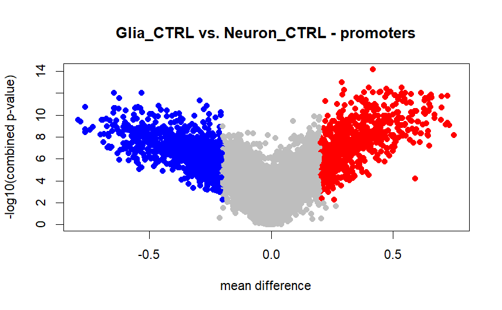

```r
# let's visualize the promoter results with a volcano plot
# use red to highlight most differential promoters
dmrs <- get.table(object = diffmeth_sorted, comparison, "promoters")
plot(dmrs[, "mean.mean.diff"],
     -log10(dmrs[, "comb.p.val"]),
     xlab = "mean difference",
     ylab = "-log10(combined p-value)",
     col = ifelse((dmrs[, "comb.p.val"] < 0.01 &
                   dmrs [, "mean.mean.diff"] > 0.2) , "red",
                  ifelse((dmrs[, "comb.p.val"] < 0.01 &
                            dmrs [, "mean.mean.diff"] < -0.2), "blue", "grey")
                  ),
     pch = 19,
     main = paste0(gsub(" \\(.*", "", comparison), " - promoters"))
```

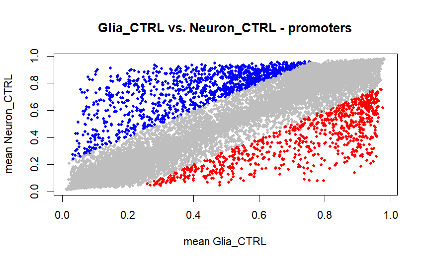

```r
#scatter plot
plot(dmrs[, "mean.mean.g1"],
     dmrs[, "mean.mean.g2"],
     xlab = "mean Glia_CTRL",
     ylab = "mean Neuron_CTRL",
     col = ifelse((dmrs[, "comb.p.val"] < 0.01 &
                     dmrs [, "mean.mean.diff"] > 0.2) , "red",
                  ifelse((dmrs[, "comb.p.val"] < 0.01 &
                            dmrs [, "mean.mean.diff"] < -0.2), "blue", "grey")
     ),
     pch = 19, cex = 0.6,
     main = paste0(gsub(" \\(.*", "", comparison), " - promoters"))
```

```r
########################################################################################################
```

### Advance analyses (Optional)

##### GO enrichment

```r
# let's perform GO enrichment analysis
BiocManager::install(version = "3.18")
n
enrich.go <- performGoEnrichment.diffMeth(rnb, diffmeth_sorted, verbose = TRUE) #takes 30-45 minutes
```

```
2026-01-15 19:03:42     Inf  STATUS STARTED Differential Methylation GO Enrichment Analysis
```

```
2026-01-15 19:03:42     Inf  STATUS     STARTED Comparison:  Glia_CTRL vs. Neuron_CTRL (based on Neuron_CTRL_vs_Glia_CTRL)
```

```
2026-01-15 19:03:42     Inf  STATUS         STARTED Ontology:  BP
```

```
2026-01-15 19:03:42     Inf  STATUS             STARTED Region Level
```

```
2026-01-15 19:03:42     Inf  STATUS                 STARTED Region Type: genes
```

```
2026-01-15 19:03:42     Inf    INFO                     Rank cutoff: 100
```

```
2026-01-15 19:05:03     Inf    INFO                     Rank cutoff: 500
```

```
2026-01-15 19:07:03     Inf    INFO                     Rank cutoff: 1000
```

```
2026-01-15 19:09:13     Inf    INFO                     Rank cutoff: 765 (auto-select)
```

```
2026-01-15 19:11:56     Inf  STATUS                 COMPLETED Region Type: genes
```

```
2026-01-15 19:11:56     Inf  STATUS                 STARTED Region Type: promoters
```

```
2026-01-15 19:11:57     Inf    INFO                     Rank cutoff: 100
```

```
2026-01-15 19:13:43     Inf    INFO                     Rank cutoff: 500
```

```
2026-01-15 19:16:15     Inf    INFO                     Rank cutoff: 1000
```

```
2026-01-15 19:18:59     Inf    INFO                     Rank cutoff: 895 (auto-select)
```

```
2026-01-15 19:21:30     Inf  STATUS                 COMPLETED Region Type: promoters
```

```
2026-01-15 19:21:30     Inf  STATUS             COMPLETED Region Level
```

```
2026-01-15 19:21:30     Inf  STATUS         COMPLETED Ontology:  BP
```

```
2026-01-15 19:21:30     Inf  STATUS         STARTED Ontology:  MF
```

```
2026-01-15 19:21:30     Inf  STATUS             STARTED Region Level
```

```
2026-01-15 19:21:30     Inf  STATUS                 STARTED Region Type: genes
```

```
2026-01-15 19:21:30     Inf    INFO                     Rank cutoff: 100
```

```
2026-01-15 19:22:19     Inf    INFO                     Rank cutoff: 500
```

```
2026-01-15 19:23:17     Inf    INFO                     Rank cutoff: 1000
```

```
2026-01-15 19:24:08     Inf    INFO                     Rank cutoff: 765 (auto-select)
```

```
2026-01-15 19:25:04     Inf  STATUS                 COMPLETED Region Type: genes
```

```
2026-01-15 19:25:04     Inf  STATUS                 STARTED Region Type: promoters
```

```
2026-01-15 19:25:04     Inf    INFO                     Rank cutoff: 100
```

```
2026-01-15 19:25:58     Inf    INFO                     Rank cutoff: 500
```

```
2026-01-15 19:26:53     Inf    INFO                     Rank cutoff: 1000
```

```
2026-01-15 19:27:49     Inf    INFO                     Rank cutoff: 895 (auto-select)
```

```
2026-01-15 19:28:43     Inf  STATUS                 COMPLETED Region Type: promoters
```

```
2026-01-15 19:28:43     Inf  STATUS             COMPLETED Region Level
```

```
2026-01-15 19:28:43     Inf  STATUS         COMPLETED Ontology:  MF
```

```
2026-01-15 19:28:43     Inf  STATUS     COMPLETED Comparison:  Glia_CTRL vs. Neuron_CTRL (based on Neuron_CTRL_vs_Glia_CTRL)
```

```
2026-01-15 19:28:43     Inf  STATUS     STARTED Comparison:  Neuron_AD vs. Neuron_CTRL (based on AD_vs_CTRL_Neuron)
```

```
2026-01-15 19:28:43     Inf  STATUS         STARTED Ontology:  BP
```

```
2026-01-15 19:28:43     Inf  STATUS             STARTED Region Level
```

```
2026-01-15 19:28:43     Inf  STATUS                 STARTED Region Type: genes
```

```
2026-01-15 19:28:43     Inf    INFO                     Rank cutoff: 100
```

```
2026-01-15 19:30:40     Inf    INFO                     Rank cutoff: 500
```

```
2026-01-15 19:33:22     Inf    INFO                     Rank cutoff: 1000
```

```
2026-01-15 19:36:13     Inf    INFO                     Rank cutoff: 2 (auto-select)
```

```
2026-01-15 19:36:46     Inf    INFO                     Could not conduct enrichment analysis as associated genes are not in GO database.
```

```
2026-01-15 19:37:23     Inf    INFO                     Could not conduct enrichment analysis as associated genes are not in GO database.
```

```
2026-01-15 19:37:23     Inf  STATUS                 COMPLETED Region Type: genes
```

```
2026-01-15 19:37:23     Inf  STATUS                 STARTED Region Type: promoters
```

```
2026-01-15 19:37:23     Inf    INFO                     Rank cutoff: 100
```

```
2026-01-15 19:39:27     Inf    INFO                     Rank cutoff: 500
```

```
2026-01-15 19:41:57     Inf    INFO                     Rank cutoff: 1000
```

```
2026-01-15 19:44:21     Inf    INFO                     Rank cutoff: 2 (auto-select)
```

```
2026-01-15 19:44:49     Inf    INFO                     Could not conduct enrichment analysis as associated genes are not in GO database.
```

```
2026-01-15 19:44:49     Inf  STATUS                 COMPLETED Region Type: promoters
```

```
2026-01-15 19:44:49     Inf  STATUS             COMPLETED Region Level
```

```
2026-01-15 19:44:49     Inf  STATUS         COMPLETED Ontology:  BP
```

```
2026-01-15 19:44:49     Inf  STATUS         STARTED Ontology:  MF
```

```
2026-01-15 19:44:49     Inf  STATUS             STARTED Region Level
```

```
2026-01-15 19:44:49     Inf  STATUS                 STARTED Region Type: genes
```

```
2026-01-15 19:44:50     Inf    INFO                     Rank cutoff: 100
```

```
2026-01-15 19:45:31     Inf    INFO                     Rank cutoff: 500
```

```
2026-01-15 19:46:13     Inf    INFO                     Rank cutoff: 1000
```

```
2026-01-15 19:46:56     Inf    INFO                     Rank cutoff: 2 (auto-select)
```

```
2026-01-15 19:47:16     Inf    INFO                     Could not conduct enrichment analysis as associated genes are not in GO database.
```

```
2026-01-15 19:47:34     Inf    INFO                     Could not conduct enrichment analysis as associated genes are not in GO database.
```

```
2026-01-15 19:47:34     Inf  STATUS                 COMPLETED Region Type: genes
```

```
2026-01-15 19:47:34     Inf  STATUS                 STARTED Region Type: promoters
```

```
2026-01-15 19:47:34     Inf    INFO                     Rank cutoff: 100
```

```
2026-01-15 19:48:21     Inf    INFO                     Rank cutoff: 500
```

```
2026-01-15 19:49:02     Inf    INFO                     Rank cutoff: 1000
```

```
2026-01-15 19:49:48     Inf    INFO                     Rank cutoff: 2 (auto-select)
```

```
2026-01-15 19:50:07     Inf    INFO                     Could not conduct enrichment analysis as associated genes are not in GO database.
```

```
2026-01-15 19:50:07     Inf  STATUS                 COMPLETED Region Type: promoters
```

```
2026-01-15 19:50:07     Inf  STATUS             COMPLETED Region Level
```

```
2026-01-15 19:50:07     Inf  STATUS         COMPLETED Ontology:  MF
```

```
2026-01-15 19:50:07     Inf  STATUS     COMPLETED Comparison:  Neuron_AD vs. Neuron_CTRL (based on AD_vs_CTRL_Neuron)
```

```
2026-01-15 19:50:07     Inf  STATUS     STARTED Comparison:  Glia_AD vs. Glia_CTRL (based on AD_vs_CTRL_Glia)
```

```
2026-01-15 19:50:07     Inf  STATUS         STARTED Ontology:  BP
```

```
2026-01-15 19:50:07     Inf  STATUS             STARTED Region Level
```

```
2026-01-15 19:50:07     Inf  STATUS                 STARTED Region Type: genes
```

```
2026-01-15 19:50:07     Inf    INFO                     Rank cutoff: 100
```

```
2026-01-15 19:51:55     Inf    INFO                     Rank cutoff: 500
```

```
2026-01-15 19:54:20     Inf    INFO                     Rank cutoff: 1000
```

```
2026-01-15 19:56:55     Inf    INFO                     Rank cutoff: 3 (auto-select)
```

```
2026-01-15 19:57:23     Inf    INFO                     Could not conduct enrichment analysis as associated genes are not in GO database.
```

```
2026-01-15 19:57:23     Inf  STATUS                 COMPLETED Region Type: genes
```

```
2026-01-15 19:57:23     Inf  STATUS                 STARTED Region Type: promoters
```

```
2026-01-15 19:57:23     Inf    INFO                     Rank cutoff: 100
```

```
2026-01-15 19:59:04     Inf    INFO                     Rank cutoff: 500
```

```
2026-01-15 20:01:28     Inf    INFO                     Rank cutoff: 1000
```

```
2026-01-15 20:03:48     Inf    INFO                     Rank cutoff: 2 (auto-select)
```

```
2026-01-15 20:04:30     Inf  STATUS                 COMPLETED Region Type: promoters
```

```
2026-01-15 20:04:30     Inf  STATUS             COMPLETED Region Level
```

```
2026-01-15 20:04:30     Inf  STATUS         COMPLETED Ontology:  BP
```

```
2026-01-15 20:04:30     Inf  STATUS         STARTED Ontology:  MF
```

```
2026-01-15 20:04:30     Inf  STATUS             STARTED Region Level
```

```
2026-01-15 20:04:30     Inf  STATUS                 STARTED Region Type: genes
```

```
2026-01-15 20:04:30     Inf    INFO                     Rank cutoff: 100
```

```
2026-01-15 20:05:15     Inf    INFO                     Rank cutoff: 500
```

```
2026-01-15 20:06:00     Inf    INFO                     Rank cutoff: 1000
```

```
2026-01-15 20:06:50     Inf    INFO                     Rank cutoff: 3 (auto-select)
```

```
2026-01-15 20:07:12     Inf    INFO                     Could not conduct enrichment analysis as associated genes are not in GO database.
```

```
2026-01-15 20:07:12     Inf  STATUS                 COMPLETED Region Type: genes
```

```
2026-01-15 20:07:12     Inf  STATUS                 STARTED Region Type: promoters
```

```
2026-01-15 20:07:12     Inf    INFO                     Rank cutoff: 100
```

```
2026-01-15 20:07:59     Inf    INFO                     Rank cutoff: 500
```

```
2026-01-15 20:08:46     Inf    INFO                     Rank cutoff: 1000
```

```
2026-01-15 20:09:36     Inf    INFO                     Rank cutoff: 2 (auto-select)
```

```
2026-01-15 20:09:58     Inf  STATUS                 COMPLETED Region Type: promoters
```

```
2026-01-15 20:09:58     Inf  STATUS             COMPLETED Region Level
```

```
2026-01-15 20:09:58     Inf  STATUS         COMPLETED Ontology:  MF
```

```
2026-01-15 20:09:58     Inf  STATUS     COMPLETED Comparison:  Glia_AD vs. Glia_CTRL (based on AD_vs_CTRL_Glia)
```

```
2026-01-15 20:09:58     Inf  STATUS COMPLETED Differential Methylation GO Enrichment Analysis
```

```r
#result is a complex nested table so let's extract some results to get an impression about the results
enrich.table.go <-enrich.go[["region"]][[comparison]][["BP"]][["promoters"]][["rankCut_500"]][["hyper"]]
class(enrich.table.go)
```

```
[1] "GOHyperGResult"
attr(,"package")
[1] "GOstats"
```

```r
summary(enrich.table.go)
```

| GOBPID | Pvalue | OddsRatio | ExpCount | Count | Size | Term |
| --- | --- | --- | --- | --- | --- | --- |
| GO:0008306 | 0.0002423932 | 7.550440 | 0.87528428 | 6 | 80 | associative learning |
| GO:0050804 | 0.0004302545 | 3.072386 | 4.91253304 | 14 | 449 | modulation of chemical synaptic transmission |
| GO:0032962 | 0.0011648626 | 60.939394 | 0.05470527 | 2 | 5 | positive regulation of inositol trisphosphate biosynthetic process |
| GO:0098664 | 0.0014814650 | 15.307619 | 0.22976212 | 3 | 21 | G protein-coupled serotonin receptor signaling pathway |
| GO:0098916 | 0.0036357035 | 2.269691 | 7.51650378 | 16 | 687 | anterograde trans-synaptic signaling |
| GO:0050890 | 0.0048125046 | 2.985459 | 3.18384658 | 9 | 291 | cognition |
| GO:0099536 | 0.0051830310 | 2.181342 | 7.80097117 | 16 | 713 | synaptic signaling |
| GO:0048583 | 0.0059359533 | 1.544862 | 40.12084332 | 55 | 3667 | regulation of response to stimulus |
| GO:0032957 | 0.0061357003 | 20.305556 | 0.12035159 | 2 | 11 | inositol trisphosphate metabolic process |
| GO:0010959 | 0.0062464368 | 2.684882 | 3.92783822 | 10 | 359 | regulation of metal ion transport |

[output cut: 13 more lines]

```r
NA
```

##### LOLA enrichment (locus overlap analysis)

```r
library(LOLA)
library(simpleCache)
lolaDest <- tempfile()
dir.create(lolaDest)
lolaDirs <- downloadLolaDbs(dest = lolaDest, dbs = "LOLACore") #downloads ca 500MB
#if download breaks with timeout error change timeout limit e.g. options(timeout=300), then try again #

#perform LOLA
enrich.lola <-performLolaEnrichment.diffMeth(rnb, diffmeth_sorted, lolaDirs[["hg19"]]) #5min
#extract some results
enrich.table.lola <- enrich.lola$region[[comparison]][["promoters"]]
enrich.table.lola <- enrich.table.lola[enrich.table.lola$userSet == "rankCut_500_hyper", ]

#plot results
lolaBarPlot(enrich.lola$lolaDb, enrich.table.lola, scoreCol = "pValueLog", orderCol = "maxRnk", pvalCut = 0.05, signifCol = "pValueLog")
lolaBoxPlotPerTarget(enrich.lola$lolaDb, enrich.table.lola, scoreCol = "pValueLog", orderCol = "maxRnk", pvalCut = 0.05, signifCol = "pValueLog")

#########################################################################################################

#export of rnbeads data
rnb.options(export.to.csv = TRUE)
rnb.run.tnt(rnb, report.dir)

#########################################################################################################

# Coordinates around specific locus
chrom <- "chr2"
start <- 177010000#112252200
end <- 177040000#112252300
sample.grouping <- rnb.sample.groups(rnb)[['Neuron_CTRL_vs_Glia_CTRL']]
rnb.plot.locus.profile(rnb, chrom, start, end, grps = sample.grouping)

#change grouping so inspect other groups, see all groupings by using names(rnb.sample.groups(rnb))
sample.grouping <- rnb.sample.groups(rnb)[['AD_vs_CTRL_Neuron']]
rnb.plot.locus.profile(rnb, chrom, start, end, grps = sample.grouping)

sample.grouping <- rnb.sample.groups(rnb)[['AD_vs_CTRL_Glia']]
rnb.plot.locus.profile(rnb, chrom, start, end, grps = sample.grouping)
```